Categorical Analysis of Loyola Ramblers

Games (2016 - present), version 2.0

Charles Hwang (LUC ’20)

Background/Motivations

●Uniqueness

○only one previous known statistical analysis on these data

had been performed

●personal interest

●Existing dataset

●More time for questions

Criteria for Dataset inclusion

●All matches between August 19, 2016 and September 12, 2022

●Loyola Ramblers’ programs playing “head-to-head” competition

include women’s softball (SB) and both women’s and men’s

soccer (WSOC, MSOC), volleyball (WVB, MVB), and basketball (WBB,

MBB)

○ Women’s and men’s Cross country, track & field, golf, and

spirit teams excluded

Variables included

●Team

●Season

●Type (regular season, conference

Tournament, postseason, etc.)

●Location (home, away, or neutral)

●Opponent

●Opponent conference

●Outcome (win, draw, or loss)

●Day of week

●Month

●Score for

●Score against

●Length (regulation vs. overtime,

etc.)

●Outcome of previous game

●Win/loss streak prior to game

●Whether or not I attended

Exploratory Data Analysis (EDA)

●All data were compiled manually in excel then read into R as a .csv file

○n = 1,203 games

●Variables selected from those easily available online1

●Conference at time of game recorded2, 3

●different conferences per sport2

●Accuracy checks

○missing data (none)

○impossible values

○similar values (Northern Iowa vs. Northern Illinois, MVC vs. MAC,

etc.)

Hypotheses/Research Questions

1. Which variable(s) are the most significant for each team?

2. Did each team perform differently during the seasons before, after,

and the successive season after the onset of the COVID-19 pandemic?

3. Did teams perform differently before and after a head coaching

change?

○WVB (after 2017), SB (after 2019), MBB (after 2020-21)

4. Do teams perform differently at home than away/Neutral?

5. Do teams perform differently when I attend?

Predictions

1. Location is significant

○Season and win/loss streak may be significant

2. Teams generally performed differently in each of the three

seasons

3. WVB did better, SB and MBB had no statistically significant

difference

4. Teams perform better at home than away

5. Teams perform better when I attend

Analyses performed

1. GLM (stepwise selection with AIC, both directions)

2-3. (a lot of) Two-proportion z-tests (α= 0.05)

4-5. χ2-tests of independence (α= 0.01)

5. likelihood ratio χ2G-test, Fisher’s exact test

[figure not shown]

(No MSOC

or WSOC)

Season Type

Location

Month Match

Length

Previous

Outcome

Win/los

s streak

#

Did I

attend?

Steps

WVB ’17, (2) Home, N 8

WVB*

0.023603

8

WBB (5)0.08098

77

WBB* Home, N

0.008321

6

MBB (3)Home, N 0.08440

98

MBB* Home, N 0.12123

88

MVB (0)

Regular

4

, 5

sets

0.05552 5

*Without season variable Score was excluded from all, opponent and conference were excluded from

some

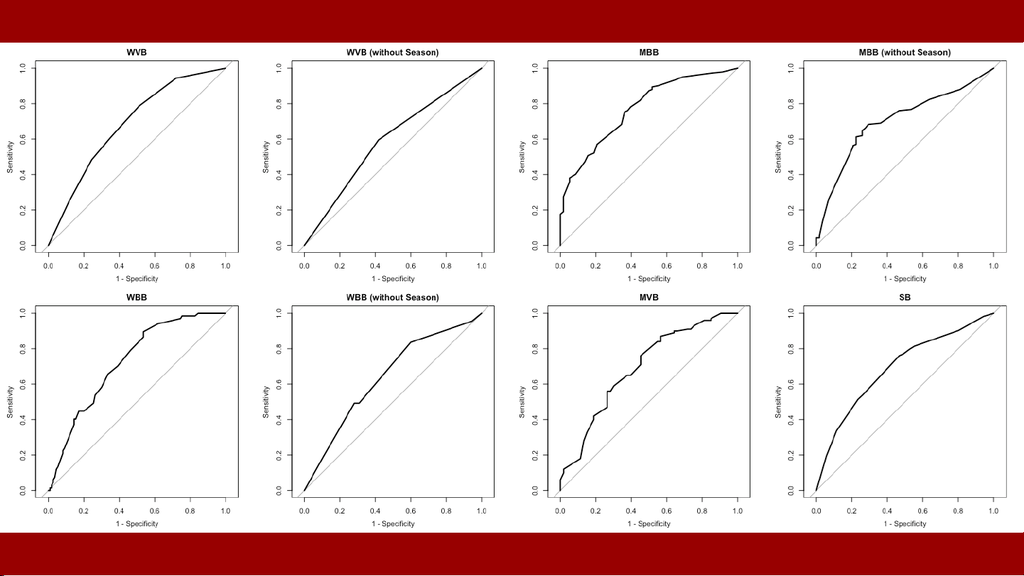

0.7044 0.5836 0.7714 0.7020

0.7248 0.6392 0.6924 0.6878

[figure not shown]

WSOC MSOC WVB WBB* MBB MVB* SB*

0 vs. 1

0.7713

9

0.7254

6

0.4435

7

0.5859

2

0.0962

5

0.04106

0.04518

0 vs. 2

0.9652

2

0.8282

5

0.9252

3

0.5221

1

0.3692

2

0.0662

0

0.1061

8

1 vs. 2

0.7894

5

0.8717

4

0.3740

3

0.2402

3

0.4201

0

0.7240

2

0.6031

8

2. Two-proportion z-tests on win % (years 0, 1, and 2 of pandemic)

*1+ WBB, 9+ MVB, 31+ SB games cancelled in 2020

[figure not shown]

*χ2(1) = z2

✝No games for men’s soccer, women’s basketball, or men’s

volleyball

3. Two-proportion z-tests on win % (before & After HC change✝)

X

-

statistic*

p-value

Win % before

Win % after 95% C.I.

WVB (2017)

14.87044

0.0001151535

0.3114754 0.6129032 (-0.446,-

0.157)

SB (2019)

3.043565 0.08105772 0.4901961 0.3818182 (-0.013,

0.229)

MBB (2021)

0.4344527 0.5098121 0.7005988 0.7575758 (-0.219,

0.105)

[figure not shown]

Home

Neutral

1Away

Win

340 103 208

Draw

10 013

Loss

180 79 270

Total

530 182 491

Win %

0.65094

0.56593

0.43686

Yes No

Total

Win

99 552 651

Draw2

221 23

Loss

44 485 529

Total

145

1,058

1,203

Win %

0.6897

0.5317

0.5507

4-5. Two-way frequency tables

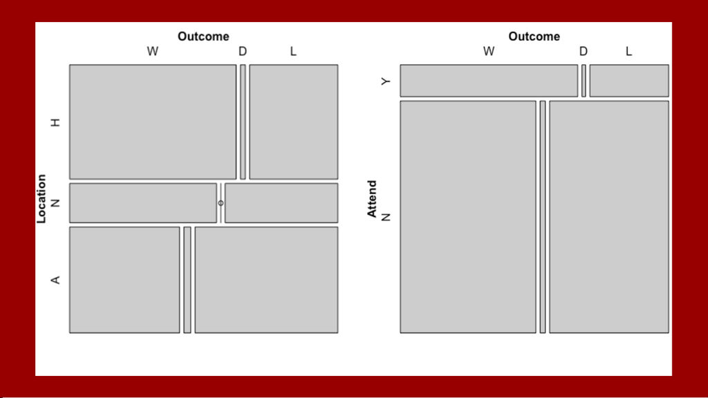

[figure not shown]

Home

N+Away1

Win

340 311

Draw

10 13

Loss

180 349

Total

530 673

Win %

0.65094

0.47177

Yes No

Total

Win2

99 573 672

Loss2

46 485 531

Total

145

1,058

1,203

Win %

0.6828

0.5416

0.5586

Odds ratio: (99*485)/(573*46) ≈

1.82164808

4-5. Two-way frequency tables (modified)

[figure not shown]

Outcome vs.

Location

Outcome vs.

Location1

Location (LR

χ2G-test1)

Outcome vs.

Attendance

Outcome vs.

Attendance

2

Attendance

2

(Fisher’s)

statistic

53.11884 39.22969 39.59474 13.31843 10.3073

p-

value

< 0.0000001

0.00000000

6

0.00000000

3

0.00128215

2

0.00132505

3

0.00129913

8

Signif. code

*** *** *** ** ** **

1Neutral and away games grouped together

2Attended draws counted as losses, non-attended draws counted as wins

4-5. χ2-tests of independence, LR χ2G-test, Fisher’s exact test

[figure not shown]

Conclusions

1. Location is the most significant variable overall (see #4) ✓

○Season is also significant

2. Most teams did not perform differently before and after the pandemic

✗

○Exceptions: MVB (p = 0.04106) and SB (p = 0.04518), 2020 vs. 2021

3. WVB did better, MBB had no difference, SB did worse (not significant) ✓

4. Teams did better at home (p < 0.00000001) ✓

Analysis

1. see #4, performance between seasons being different also makes sense

○Other variables (previous match, match length, month) being

statistically significant for individual programs is interesting

2. This is interesting because I expected training restrictions, strength &

conditioning, match conditions (e.g., no fans), etc. to be different, but it

makes sense that they are not statistically significant at α= 0.05

3. This was expected as I followed all the teams before and after

○ Softball getting “worse” could be attributed to non-con scheduling

4. This makes sense, most teams perform better at home

[figure not shown]

Analysis

5.

Randomness and independence assumptions

●my attendance of matches was not random

○Intuitively, fans attend matches if they want to

○Likelihood of attendance may be dependent on past

attendance, gameday promotions/giveaways, distance, etc.

●Team performance is likely not independent

○Performance in a given match may depend on previous

matches

●However, it appears these assumptions are not “badly” violated.

Improvements made

●Further analysis on the underlying reasons for results ✓

●Reviewing test assumptions (randomness, independence, etc.)

✓

●Updating dataset and results with new data

Future improvements

●Adding other variables and interaction terms

○Private vs. public, days since previous game, date, time, duration,

“official” attendance, national poll rankings, distance from campus,

distance travelled, ticket price, whether there was a

promotion/giveaway, etc.

●Tests on non-conference and conference records instead of overall record

●Adding non-head-to-head teams (with final ranking/position as outcome)

●Researching how to code draws in Glm for soccer

●Predictive analytics (CART, random forest, etc.), machine learning

●Time-series analysis

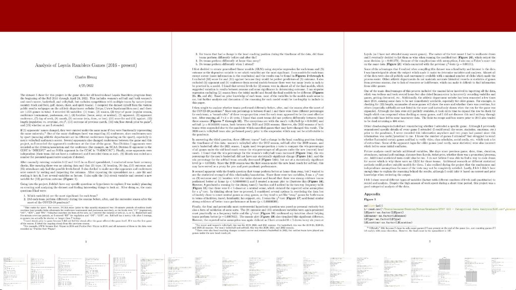

Spring 2022 Project report (3 pages) and Code Appendix (19 pages)

[figure not shown]

References

1. LoyolaRamblers.com (and its thousands of

subpages)

2. Other teams’ athletics websites (to verify older

matches and conference affiliations)

3. Wikipedia (to verify conference affiliations)

[figure not shown]

Questions?